# Analysis: Death from cancer in Scotland

Cancer in Scotland

Lesley Duff

2023-11-13

# Death

## Background

We wish to see where cancer fits into the overall pattern of death in Scotland. The [National Records of Scotland](https://www.nrscotland.gov.uk/) (NRS) maintain official death statistics for Scotland.

This analysis utilises NRS data which is © Crown Copyright 2023.

When a death is registered, it is common for a number of diseases or conditions to be recorded on the death certificate. NRS apply the WHO rules to determine which of these conditions is the underlying cause of death.” - [Death Certificates and Coding the Causes of Death](https://www.nrscotland.gov.uk/statistics-and-data/statistics/statistics-by-theme/vital-events/deaths/deaths-background-information/death-certificates-and-coding-the-causes-of-death)

**Source:**  
[Table 1: All ages age-standardised death rates for all causes and certain selected causes, Scotland, 1994 to 2022](https://www.nrscotland.gov.uk/statistics-and-data/statistics/statistics-by-theme/vital-events/deaths/age-standardised-death-rates-calculated-using-the-esp).  
NRS Last update: 19 September 2023.

Definition: `rate` is deaths per 100,000 people in Scotland using. The NRS data is age-standardised using the European Standard Population.

There are **13** categories of causes recorded in the dataset.

| cause |
| --- |
| Accidents |
| Alcohol-specific |
| All causes |
| Cancer (malignant neoplasms: 140-208 /C00-97) |
| Cerebrovascular disease (stroke:430-438 / I60-69) |
| Chronic Obstructive Pulmonary Disease NEW DEF(490-492,496 / J40-44) |
| Covid-19 |
| Dementia and Alzheimer's |
| Diseases of the circulatory system(390-459 / I00-I99) |
| Diseases of the respiratory system(460-519 / J00-99) |

[output cut: 3 more lines]

As you can see these are formal technical names. For simplifying ongoing work the following substitutions have been made and called `cause_simple`.

| cause_simple |
| --- |
| Accidents |
| Alcohol-specific |
| All causes |
| Cancer |
| Cerebrovascular disease |
| Circulatory |
| COVID-19 |
| Dementia and Alzheimer's |
| Drug related |
| Heart |

[output cut: 3 more lines]

## Analysis

### How does death from cancer in Scotland compare to other causes?

#### Overview

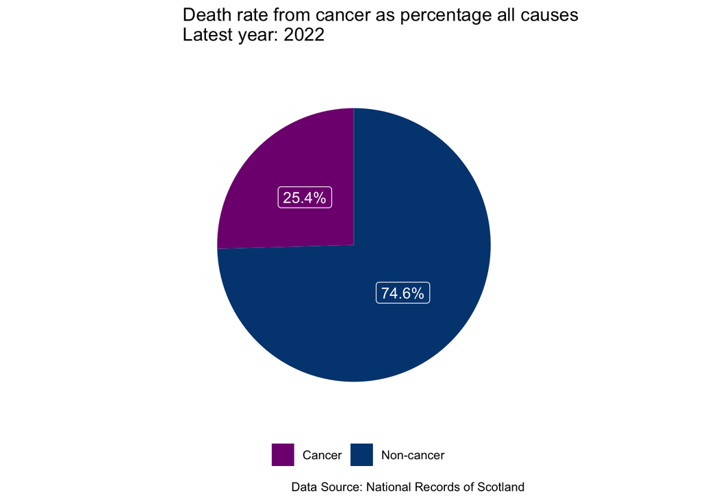

This shows the proportion of deaths from cancer compared to all other causes combined for the most recently available year of data - 2022.

At time of writing cancer accounts for almost exactly a quarter of all deaths.

#### Change over time for all causes of death

##### By proportion

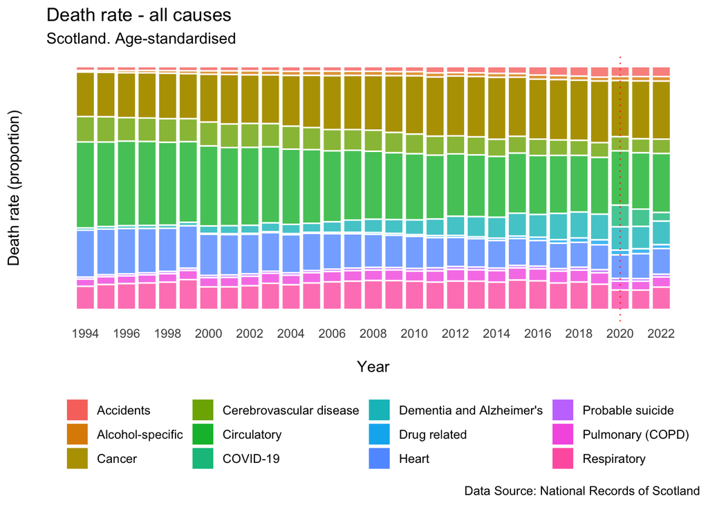

This shows how the **proportion** of deaths is changing over time by cause.  
Cancer is the thirds bar from the top. A dotted red vertical line marks 2020 -the start of the COVID-19 pandemic. After 2020 many other non-COVID-19 conditions are once again worsening, however, **the rate of cancer deaths is improving**, albeit in a very small way. You can see this in the precise numbers if you filter the following table by ‘Cancer’.

N.B. This **does not** show changes in *amount*. What it does show is the relationship between all possible causes. If a particular cause bar is getting larger like dementia it is becoming worse or if it is decreasing like circulatory then people are becoming less likely to die from that cause.

For the latter it would indicate change in that a condition that people used to die of more in the past they’re now dying of *something else* instead, so in those cases it’s the ‘something else’ that has worsened and would be the things to take especial note of and investigate further.

A good example is the emergence in 2020 of COVID-19. People were dying from this new cause instead of the kind of thing they would normally have died of, including cancer. People with cancer and due to certain treatments can have weaker immune systems and be more vulnerable to disease. The bar for cancer certainly seems to shrink more than other causes in 2020. A further suggestion would be to investigate if more people with Cancer and/or Respiratory were more likely to die if they subsequently caught COVID.

##### By Rate

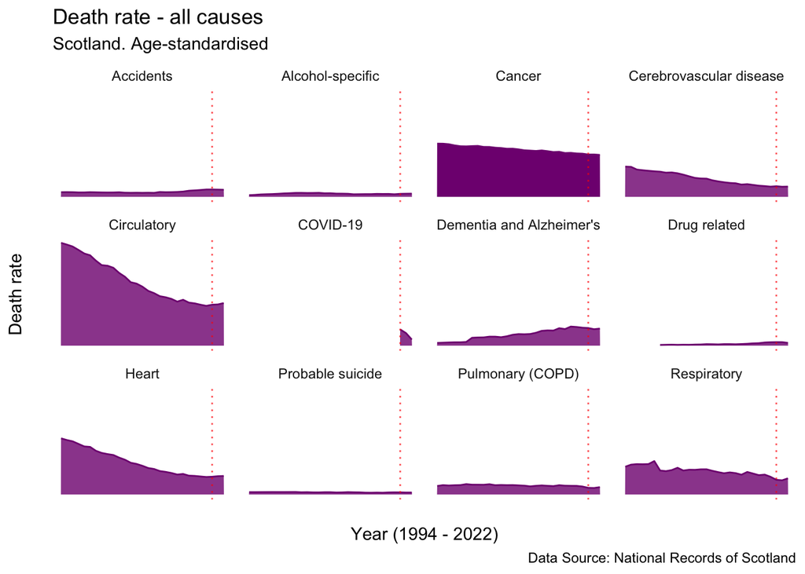

The good news is that rates of cancer have reduced from 1994 - 2022. However, the degree of reduction is gradual and isn’t reducing as quickly as for some other causes.

Of note is Dementia and Alzheimer’s which seems very out of step with other causes. It is the only one to have sustained growth from the first available year. These conditions are often associated with old age and at the start of the data “baby boomers” born during/after the Second World War have aged from their 50s to 80s.

It’s worth considering whether the rise in dementia as a cause of death might be partially contributing to lowering the main cause of death being listed as cancer. Are more older people dying of dementia *instead* of cancer which may then make it look as if cancer rates have improved more than is really the case? Again this may require further analysis by those who know which people have been living with *multiple* conditions at the time of death.

Other good news relating to other causes is the long-term impressive reductions in death from circulatory/heart/cerebrovasular (usually strokes). This should serve as an inspiring example of improved emphasis on preventative work treating things like e.g. High Blood Pressure with medication and paramedics being able to administer clot-busting drugs in emergencies may have reduced the rate of death. If so, that would be an encouraging example that substantial change is possible when better prevention strategies/treatments become available.

The slight uptick in some conditions since the start of COVID-19 should be watched carefully. Health practitioners are still discovering more features of e.g. “Long COVID-19” which may be worsening some pre-existing conditions.

#### Table: Rate of death compared to other causes by year

**Tip:** To filter by a particular condition type in the ‘Search’ box.

|  | year | rate | cause_simple |
| --- | --- | --- | --- |
| 1 | 2022 | 1171.2 | All causes |
| 2 | 2022 | 302.4 | Circulatory |
| 3 | 2022 | 298 | Cancer |
| 4 | 2022 | 131.4 | Heart |
| 5 | 2022 | 121.2 | Dementia and Alzheimer's |
| 6 | 2022 | 114.5 | Respiratory |
| 7 | 2022 | 73.1 | Cerebrovascular disease |
| 8 | 2022 | 52 | Pulmonary (COPD) |
| 9 | 2022 | 50.6 | Accidents |
| 10 | 2022 | 43.6 | COVID-19 |

[output cut: 335 more lines]

#### Recent change in rate

|  | year | rate | cause_simple | rate_previous | rate_change | rate_change_pct |
| --- | --- | --- | --- | --- | --- | --- |
| 1 | 2022 | 1171.2 | All causes | 1180.6 | -9.4 | -0.8 |
| 2 | 2022 | 302.4 | Circulatory | 293 | 9.4 | 3.1 |
| 3 | 2022 | 298 | Cancer | 301.1 | -3.1 | -1 |
| 4 | 2022 | 131.4 | Heart | 129.7 | 1.7 | 1.3 |
| 5 | 2022 | 121.2 | Dementia and Alzheimer's | 116.9 | 4.3 | 3.5 |
| 6 | 2022 | 114.5 | Respiratory | 100.6 | 13.9 | 12.1 |
| 7 | 2022 | 73.1 | Cerebrovascular disease | 72.1 | 1 | 1.4 |
| 8 | 2022 | 52 | Pulmonary (COPD) | 46 | 6 | 11.5 |
| 9 | 2022 | 50.6 | Accidents | 51.7 | -1.1 | -2.2 |
| 10 | 2022 | 43.6 | COVID-19 | 89.4 | -45.8 | -105 |

[output cut: 3 more lines]

##### Improving since previous year available - 2021

These are what got ‘better’ in terms of death rate between the latest two years of data.

|  | cause_simple | rate_change_pct |
| --- | --- | --- |
| 1 | COVID-19 | -105 |
| 2 | Drug related | -26.3 |
| 3 | Accidents | -2.2 |
| 4 | Cancer | -1 |
| 5 | All causes | -0.8 |

Conclusion: **rates of cancer deaths have improved for the most recent year**.

It’s not possible to tell from our data whether any of the screening or vacination programmes contribute in any way to the improvement. And the improvement is so small it’s almost static.

Of interest is that in spite of a great deal of negative publicity about Scottish drug related deaths being worse than many other countries there *has* been an improvement in *rates* recently.

##### Worsening since previous year available - 2021

Ordered by greatest percentage change (worst) to least.

|  | cause_simple | rate_change_pct |
| --- | --- | --- |
| 1 | Respiratory | 12.1 |
| 2 | Pulmonary (COPD) | 11.5 |
| 3 | Dementia and Alzheimer's | 3.5 |
| 4 | Circulatory | 3.1 |
| 5 | Alcohol-specific | 2.6 |
| 6 | Cerebrovascular disease | 1.4 |
| 7 | Probable suicide | 1.4 |
| 8 | Heart | 1.3 |

This category includes things like flu and pneumonia. There is a flu vacination programme in Scotland, do they have more data available that could be checked?

**Conclusion: Respiratory conditions have worsened the most**.

Keep an eye on issues relating to Respiratory and Pulmanary as these worsened the most in the last two years.

**Conclusion: Preventable causes of death like alcohol and suicide have risen**.

More work needs to be done to target these.